# Project 1: [216]Group 52

Winston Mai, Caixia Zhang, Jiahui Huang, Mary Guo, Yaoying Cai, Yupeng Zhang

29 September, 2020

## How to display data badly: write up

[output not shown]

[figure not shown]

[output not shown]

```r
knitr::include_graphics("C:\\R File\\Stat 20 Input\\Project_Pic2.png")
```

Works cited

“Commentaries,” The American Statistician, May, 1984, Vol, 38, No.2

“Ideological Placement of Each Source’s Audience,” Pew Resource Center, January 26, 2016.

## Maternal Smoking and Infant Health

```r
babies <- read.csv("C:\\R File\\Stat 20 Input\\babies.csv",header = TRUE)
# check that it looks as you expect
str(babies)
```

```
## 'data.frame':    1236 obs. of  3 variables:
##  $ X    : int  1 2 3 4 5 6 7 8 9 10 ...
##  $ bwt  : int  120 113 128 123 108 136 138 132 120 143 ...
##  $ smoke: int  0 0 1 0 1 0 0 0 0 1 ...
```

```r
head(babies)
```

```
##   X bwt smoke
## 1 1 120     0
## 2 2 113     0
## 3 3 128     1
## 4 4 123     0
## 5 5 108     1
## 6 6 136     0
```

We use str() and head() function to get a sense of what is in the data set and how it looks like in the excel file. Before doing the summaries and analysis using R coding, we suppose that the babies in the non-smoking group will have a heavier weight on average than the babies in the smoking group.

### Numerical summaries of the data

```r
babies<-read.csv("C:\\R File\\Stat 20 Input\\babies.csv")
smokers <- subset(babies, smoke==1)
non_smokers<-subset(babies,smoke==0)
#the average weight of babies in the smoke group
mean(smokers$bwt)
```

```
## [1] 114.1095
```

```r
#the average weight of babies in the non-smoke group
mean(non_smokers$bwt)
```

```
## [1] 123.0472
```

```r
#the five-number summaries of baby's weight in the smoke group
summary(smokers$bwt,c(0,0.25,0.5,0.75,1),type=1)
```

```
##    Min. 1st Qu.  Median    Mean 3rd Qu.    Max.
##    58.0   102.0   115.0   114.1   126.0   163.0
```

```r
#the five-number summaries of baby's weight in the non-smoke group
summary(non_smokers$bwt,c(0,0.25,0.5,0.75,1),type=1)
```

```
##    Min. 1st Qu.  Median    Mean 3rd Qu.    Max.
##      55     113     123     123     134     176
```

```r
n<-length(smokers$bwt)
#the standard deviation of baby's weight in the smoke group
sd(smokers$bwt)*sqrt((n-1)/n)
```

```
## [1] 18.08024
```

```r
n<-length(non_smokers$bwt)
#the standard deviation of baby's weight in the non-smoke group
sd(non_smokers$bwt)*sqrt((n-1)/n)
```

```
## [1] 17.38696
```

### Graphical summaries of the data

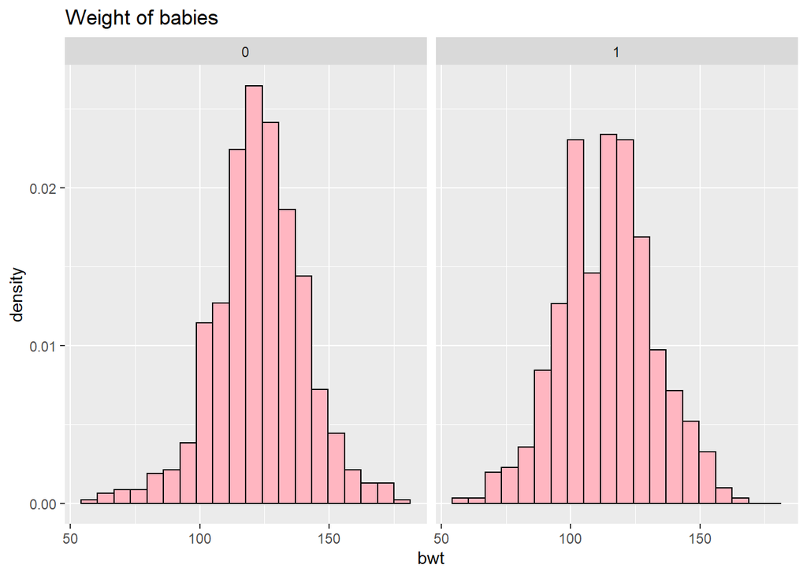

```r
library(ggplot2)
library(dplyr)
babies <- filter(babies, smoke <= 1)
ggplot(babies) + geom_histogram(aes(x = bwt, y = ..density..), bins = 20, fill = 'light pink', color = 'black') + ggtitle("Weight of babies") + facet_wrap(~smoke)
```

```r
"the distribution of smoke and nonsmoke histograms do not have a huge difference. But we can tell that there are more nonsmokers' babies in the samples."
```

```
## [1] "the distribution of smoke and nonsmoke histograms do not have a huge difference. But we can tell that there are more nonsmokers' babies in the samples."
```

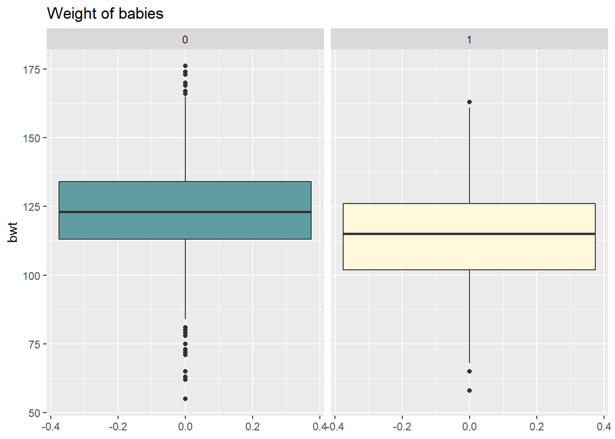

```r
ggplot(babies) + geom_boxplot(aes(y = bwt), fill = c("cadetblue", "cornsilk")) + ggtitle("Weight of babies") + facet_wrap(~smoke)
```

```r
"the median point, 25th percentile, and 75th percentile of smokers' babies are lower than nonsmokers'. There are more outliers in the boxplot of Nonsmokers' babies."
```

```
## [1] "the median point, 25th percentile, and 75th percentile of smokers' babies are lower than nonsmokers'. There are more outliers in the boxplot of Nonsmokers' babies."
```

### Discussion and conclusion

By analyzing the numerical and graphical summaries of the data, we conclude that maternal smoking is harmful to fetal health, at least it will affect the birth weight on average as the data showed. The numerical summaries present us with numbers that babies with non-smoking habits mother are heavier in general, while the boxplot delivers a visual graphic to enhance our understanding with the interquartile range rule to see if there are outliers. The histograms show that both smoking and non-smoking data groups are in a normal distribution. In the five-number summaries, we can see that 4 out of 5 numbers in the non-smoking group are greater than the smoking group as expected. Interestingly, we see that the minimum in the non-smoking group is smaller. The lightest baby has a non-smoking mother indicates that there are some other confounding factors that will affect the baby’s weight. The food consumed during pregnancy, hours of sleep, and lifestyles of the mothers are some factors that will significantly determine the baby’s weight and health.